# Morphology WFS - Fancy bits

Lauren O’Brien

2019-12-12

Some parameters might be worth presenting at Observation level in a summarised manner.

These can be appended to any version of the draft service.

```r
options(stringsAsFactors = FALSE, scipen = 999)
library(sf)
library(tidyverse)

today <- '20191101'
sit_datafile <- file.path(getwd(), 'SALI_DATA',
                          paste0('SALI_SIT-data_', today, '.rds'))
decode_datafile <- file.path(getwd(), 'SALI_DATA',
                             paste0('SALI_SIT-data_decodes_', today, '.rds'))

sit_data <- readRDS(sit_datafile)
decodes  <- readRDS(decode_datafile)
```

### Abbreviated parameters

Some site and observation-level parameters can have multiple records, but these can be reported in a simplified format.

#### Maximum site disturbance

Note that only 132 observations currently have more than one disturbance recorded, and at least one is just a duplicate, where the same disturbance code was entered twice.

```r
max_dist <-
  dplyr::select(sit_data[['ODS']],
                PROJECT_CODE, SITE_ID, OBS_NO, DISTURB_NO, DISTURB_TYPE) %>%
  group_by(PROJECT_CODE, SITE_ID, OBS_NO) %>%
  summarise(DISTURBANCE = as.character(max(as.integer(DISTURB_TYPE))))

head(max_dist)
```

```
## # A tibble: 6 x 4
## # Groups:   PROJECT_CODE, SITE_ID [6]
##   PROJECT_CODE SITE_ID OBS_NO DISTURBANCE
##   <chr>          <int>  <int> <chr>
## 1 3MC                1      1 7
## 2 3MC                2      1 7
## 3 3MC                3      1 7
## 4 3MC                4      1 7
## 5 3MC                5      1 7
## 6 3MC                6      1 2
```

#### Landscape microrelief presence

The following simplifies the SALI microrelief records down to ‘present’/‘confirmed absent’/‘not recorded’, for ‘landscape’ microrelief only - that which is controlled by inherent soil and parent material properties. As such, the gilgai types are retained, along with karst and mound/depression microrelief. Excluded are biotic microrelief (as its often ephemeral/changeable), limited-extent features like sinkholes and springs, and microrelief induced by loss of vegetation cover (e.g. terracettes and slumps).

```r
gilgai <-
  dplyr::select(sit_data[['OMC']],
                PROJECT_CODE, SITE_ID, OBS_NO, MICRO_NO, MICRO_TYPE) %>%
  group_by(PROJECT_CODE, SITE_ID, OBS_NO) %>%
  summarise(GILGAI_PRESENT = {
    if (all(is.na(MICRO_TYPE))) {
      NA_character_
    } else if (any(MICRO_TYPE %in% c('A', 'C', 'G', 'K', 'L', 'M', 'N'))) {
      'Yes'
    } else if (any(MICRO_TYPE == 'Z')) {
      'No'
    } else {
      NA_character_
    }
  })

head(gilgai)
```

```
## # A tibble: 6 x 4
## # Groups:   PROJECT_CODE, SITE_ID [6]
##   PROJECT_CODE SITE_ID OBS_NO GILGAI_PRESENT
##   <chr>          <int>  <int> <chr>
## 1 3MC               37      1 Yes
## 2 3MC               45      1 Yes
## 3 3MC               66      1 Yes
## 4 3MC              104      1 Yes
## 5 3MC              105      1 Yes
## 6 3MC              107      1 Yes
```

#### Total surface coarse fragments

Multiple records can be created for surface coarse fragments where e.g. poorly sorted lag gravels exist. Below, surface coarse fragment data is simplified to report total abundance category, and then both the maximum and most abundant size fractions observed. Lithology and shape are omitted for now as they may not be highly relevant to modelling e.g. surface water infiltration.

```r
# decode coarse frag abundance categories to percentage ranges - see Yellow Book
cf_abunds <- tribble(~ABUND, ~LO, ~MID, ~HI,
                        0,   0,    0,   0,
                        1, 0.1,  1.5,   2,
                        2,   2,    6,  10,
                        3,  10,   15,  20,
                        4,  20,   35,  50,
                        5,  50,   70,  90,
                        6,  90,   95, 100)

tot_abund <- function(x = NULL) {
  # x is a vector of categories
  filt <- sapply(na.omit(x), function(y) which(cf_abunds$ABUND == y)) # loooool
  if(length(filt) == 0) { return(NA_character_) }
  poss <- cf_abunds[filt,  ]
  opts <- c(sum(poss$LO), sum(poss$MID), sum(poss$HI))
  check <- opts <= 100
  if(all(check == FALSE)) { return('6') }
  if(all(opts[check] == 0)) { return('0') }
  catout <- which(cf_abunds$HI > max(opts[check == TRUE]))[1]
  as.character(cf_abunds$ABUND[catout])
}

max_scf <-
  dplyr::select(sit_data[['OCF']],
                PROJECT_CODE, SITE_ID, OBS_NO, SURF_FRAG_NO, ABUNDANCE,
                SURF_FRAG_SIZE) %>%
  rename(SURF_FRAG_ABUND = ABUNDANCE) %>%
  # handle historical code '-'
  mutate_if(is.character, list(~na_if(., '-'))) %>%
  group_by(PROJECT_CODE, SITE_ID, OBS_NO) %>%
  summarise(SURF_FRAG_TOTAL_ABUND =
              ifelse(n() == 1, SURF_FRAG_ABUND, tot_abund(SURF_FRAG_ABUND)),
            SURF_FRAG_MAX_SIZE =
              ifelse(n() == 1, SURF_FRAG_SIZE,
                     as.character(max(SURF_FRAG_SIZE, na.rm = TRUE))),
            SURF_FRAG_DOM_SIZE =
              ifelse(n() == 1, SURF_FRAG_SIZE,
                     SURF_FRAG_SIZE[which(SURF_FRAG_ABUND == max(SURF_FRAG_ABUND))][1])) %>%
  ungroup()
# TODO get a test suite going for this
head(max_scf)
```

```
## # A tibble: 6 x 6
##   PROJECT_CODE SITE_ID OBS_NO SURF_FRAG_TOTAL~ SURF_FRAG_MAX_S~ SURF_FRAG_DOM_S~
##   <chr>          <int>  <int> <chr>            <chr>            <chr>
## 1 3MC               87      1 1                4                4
## 2 3MC               91      1 2                2                2
## 3 3MC               92      1 2                2                2
## 4 3MC               93      1 2                2                2
## 5 3MC               94      1 1                2                2
## 6 3MC               99      1 2                2                2
```

#### Total Rock Outcrop

Very few multiple outcrop records exist, but where they do, total abundance can be reported.

```r
# decode outcrop abundance categories
oc_abunds <- tribble(~ABUND, ~LO, ~MID, ~HI,
                        0,   0,    0,   0,
                        1, 0.1,  1.5,   2,
                        2,   2,    6,  10,
                        3,  10,   15,  20,
                        4,  20,   35,  50,
                        5,  50,   75, 100)

tot_abund <- function(x = NULL) {
  # x is a vector of categories
  filt <- sapply(na.omit(x), function(y) which(oc_abunds$ABUND == y))
  if(length(filt) == 0) { return(NA_character_) }
  poss <- oc_abunds[filt,  ]
  opts <- c(sum(poss$LO), sum(poss$MID), sum(poss$HI))
  check <- opts <= 100
  if(all(check == FALSE)) { return('5') }
  if(all(opts[check] == 0)) { return('0') }
  catout <- which(oc_abunds$HI > max(opts[check == TRUE]))[1]
  as.character(oc_abunds$ABUND[catout])
}

max_outcrop <-
  dplyr::select(sit_data[['OTC']],
                PROJECT_CODE, SITE_ID, OBS_NO, OUTCROP_NO, ABUNDANCE, LITH_CODE) %>%
  rename(OUTCROP_ABUND = ABUNDANCE) %>%
  # handle historical code '-'
  mutate_if(is.character, list(~na_if(., '-'))) %>%
  group_by(PROJECT_CODE, SITE_ID, OBS_NO) %>%
  summarise(OUTCROP_TOTAL_ABUND =
              ifelse(n() == 1, OUTCROP_ABUND, tot_abund(OUTCROP_ABUND)),
            OUTCROP_DOM_LITH_CODE = ifelse(n() == 1, LITH_CODE,
                     LITH_CODE[which(OUTCROP_ABUND == max(OUTCROP_ABUND))][1]))

head(max_outcrop)
```

```
## # A tibble: 6 x 5
## # Groups:   PROJECT_CODE, SITE_ID [6]
##   PROJECT_CODE SITE_ID OBS_NO OUTCROP_TOTAL_ABUND OUTCROP_DOM_LITH_CODE
##   <chr>          <int>  <int> <chr>               <chr>
## 1 3MC               46      1 <NA>                M
## 2 3MC               91      1 2                   SA
## 3 3MC               92      1 2                   SA
## 4 3MC              115      1 3                   SA
## 5 3MC              119      1 2                   SA
## 6 3MC              187      1 1                   SA
```

NB: check for any sites with both outcrop and SCF maxed out…

### Profile summary parameters

Many summaries of soil profile characteristics can be reported at the Observation level. These include a number that have been specifically requested for SLGA II, others from the ASRIS tech spec (v1.6), and others can be derived from diagnostic criteria used in the ASC. More may be added, potentially on request.

- Depth of A1 horizon
- Total depth of A horizons
- Depth to B2 horizon
- Depth to impeding layer (rock, pan etc)
- Depth of solum
- Depth of observation
- Number of named horizons
- Name of deepest horizon (can help with interpretation of DOA)
- Min and Max A and B textures
- Presence/absence of bleached A2 horizon
- ‘duplexiness’ (clay content contrast between A and B plus sharpness of change)
- hardsetting status (T/F/NA)
- Surface horizon colour, B2 colour (as ASC colour class and hex)

#### Depth of A1

```r
d_A1 <-
  dplyr::select(sit_data[['HOR']],
                PROJECT_CODE, SITE_ID, OBS_NO,
                DESIGN_MASTER, DESIGN_NUM_PREFIX, DESIGN_SUBDIV, LOWER_DEPTH) %>%
  dplyr::filter(DESIGN_MASTER %in% c('A', 'A?')) %>%
  dplyr::filter(is.na(DESIGN_NUM_PREFIX)) %>%
  dplyr::filter(DESIGN_SUBDIV %in% c(1, 10, 11, 12, 13, 14, 15)) %>%
  group_by(PROJECT_CODE, SITE_ID, OBS_NO) %>%
  summarise(DEPTH_OF_A1 = max(LOWER_DEPTH, na.rm = TRUE))

# TODO check whether A with no subdiv should count as A1 in this context
```

#### Total depth of A

```r
d_A <-
  dplyr::select(sit_data[['HOR']],
                PROJECT_CODE, SITE_ID, OBS_NO,
                DESIGN_MASTER, DESIGN_NUM_PREFIX, LOWER_DEPTH) %>%
  dplyr::filter(DESIGN_MASTER %in% c('A', 'A?')) %>%
  dplyr::filter(is.na(DESIGN_NUM_PREFIX)) %>%
  group_by(PROJECT_CODE, SITE_ID, OBS_NO) %>%
  summarise(DEPTH_OF_A = max(LOWER_DEPTH, na.rm = TRUE))
```

#### Depth to B2

```r
d_B2 <-
  dplyr::select(sit_data[['HOR']],
                PROJECT_CODE, SITE_ID, OBS_NO,
                DESIGN_MASTER, DESIGN_NUM_PREFIX, DESIGN_SUBDIV, UPPER_DEPTH) %>%
  dplyr::filter(DESIGN_MASTER %in% c('B', 'B?')) %>%
  dplyr::filter(is.na(DESIGN_NUM_PREFIX)) %>%
  dplyr::filter(DESIGN_SUBDIV %in% c(2, seq(20, 29))) %>%
  group_by(PROJECT_CODE, SITE_ID, OBS_NO) %>%
  summarise(DEPTH_TO_B2 = min(UPPER_DEPTH, na.rm = TRUE))
```

#### Depth to impeding layer

The ASRIS specs define impeding layers as a result of chemical toxicity, chemical deficiency, direct physical impedance, or permanent water table, in the context of effects on agricultural plants (Table 29). The following focuses only on physical and hydrological impedance. Note that many non-agricultural plants are not affected by these impedances, particularly the water table depth (e.g. mangroves).

Parameters examined below are calculated depth to R horizon, depth to continuous cemented pan, and depth to permanent water table.

Note: Depth to R horizon is sometimes also recorded at the observation level, but sigificant data quality problems in SALI mean that this field is currently unusable. Known issues: * large number of values recorded in centimeters rather than meters, inconsistently within and between projects * obvious discrepancies between profile descriptions and stated depth to R. * obvious nonsense values e.g. 999

```r
d_2r_hor <- dplyr::filter(sit_data[['HOR']], DESIGN_MASTER == 'R') %>%
  dplyr::select(PROJECT_CODE, SITE_ID, OBS_NO, UPPER_DEPTH) %>%
  group_by(PROJECT_CODE, SITE_ID, OBS_NO) %>%
  summarise(DEPTH_R_HOR = min(UPPER_DEPTH, na.rm = TRUE))

d_pan <-
  dplyr::filter(sit_data[['HPA']], !is.na(CEMENTATION)) %>%
  dplyr::filter(!(CEMENTATION %in% c('0', '1'))) %>%
  dplyr::filter(CONTINUITY == 'C') %>%
  dplyr::select(PROJECT_CODE, SITE_ID, OBS_NO, HORIZON_NO, PAN_NO,
                CEMENTATION) %>%
  inner_join(.,
             dplyr::select(sit_data[['HOR']],
               PROJECT_CODE, SITE_ID, OBS_NO, HORIZON_NO, UPPER_DEPTH),
             by = c('PROJECT_CODE', 'SITE_ID', 'OBS_NO', 'HORIZON_NO')) %>%
  group_by(PROJECT_CODE, SITE_ID, OBS_NO) %>%
  summarise(DEPTH_HARDPAN = min(UPPER_DEPTH, na.rm = TRUE))

# TODO check if pans should also be restricted by type

d_pwt <- dplyr::filter(sit_data[['OBS']],
                       FREE_WATER_FLAG == 'Y' | !is.na(DEPTH_WATER)) %>%
  dplyr::select(PROJECT_CODE, SITE_ID, OBS_NO, FREE_WATER_FLAG, DEPTH_WATER) %>%
  # many CTAP sites have DEPTH_WATER == 0 but the soils are described as dry
  mutate(DEPTH_WATER =
           ifelse(PROJECT_CODE == 'CTAP' & DEPTH_WATER == 0, NA, DEPTH_WATER)) %>%
  filter(!is.na(DEPTH_WATER)) %>%
  # inconsistent recording in -ve or +ve units so:
  mutate(DEPTH_WATER = abs(DEPTH_WATER))
  # consider the unit to be m BGL
  # Note: there will be a few in ETA that are now wrong, mostly in the 0-0.3m
  # range where sampling was done in the East Trinity Remediation Area. These
  # are geographically restricted and rare so are left for now

d_phys_imp <- reduce(list(d_2r_hor, d_pan, d_pwt), full_join,
                     by = c('PROJECT_CODE', 'SITE_ID', 'OBS_NO')) %>%
  rowwise() %>%
  mutate(DEPTH_TO_IMPEDANCE = min(DEPTH_R_HOR, DEPTH_HARDPAN, DEPTH_WATER,
                           na.rm = TRUE)) %>%
  dplyr::select(PROJECT_CODE, SITE_ID, OBS_NO, DEPTH_TO_IMPEDANCE)
```

#### Depth of Solum

There’s no easy way to truncate those where a non-A or B horizon interrupts the profile sequence (e.g. distinguishing A-B-Db1-Db2-2A-2B from A-B-2B), but these are going to be rare and the non A/B horizons may not impede plant growth, so IMO still count as solum materials.

```r
d_sol <-
  dplyr::select(sit_data[['HOR']],
                PROJECT_CODE, SITE_ID, OBS_NO, DESIGN_NUM_PREFIX,
                DESIGN_MASTER, LOWER_DEPTH) %>%
  dplyr::filter(is.na(DESIGN_NUM_PREFIX)) %>%
  dplyr::filter(grepl('A|B', DESIGN_MASTER)) %>%
  group_by(PROJECT_CODE, SITE_ID, OBS_NO) %>%
  summarise(DEPTH_OF_SOLUM = max(LOWER_DEPTH, na.rm = TRUE))
```

#### Depth of observation

This is just the maximum recorded horizon depth.

```r
d_obs <-
   dplyr::select(sit_data[['HOR']],
                PROJECT_CODE, SITE_ID, OBS_NO, LOWER_DEPTH) %>%
  group_by(PROJECT_CODE, SITE_ID, OBS_NO) %>%
  summarise(DEPTH_OBSERVED = max(LOWER_DEPTH, na.rm = TRUE))
```

May as well put all the depths together and check for crazy

```r
all_depths <- reduce(list(d_A1, d_A, d_B2, d_phys_imp, d_sol, d_obs),
                   full_join, by = c('PROJECT_CODE', 'SITE_ID', 'OBS_NO'))
head(all_depths)
```

```
## # A tibble: 6 x 9
## # Groups:   PROJECT_CODE, SITE_ID [6]
##   PROJECT_CODE SITE_ID OBS_NO DEPTH_OF_A1 DEPTH_OF_A DEPTH_TO_B2
##   <chr>          <int>  <int>       <dbl>      <dbl>       <dbl>
## 1 3MC                1      1        0.45       0.45        0.45
## 2 3MC                2      1        0.1        0.1         0.1
## 3 3MC                3      1        0.09       0.09        0.09
## 4 3MC                4      1        0.32       0.32        0.32
## 5 3MC                5      1        0.12       0.12        0.12
## 6 3MC                9      1        0.3        0.3         0.3
## # ... with 3 more variables: DEPTH_TO_IMPEDANCE <dbl>, DEPTH_OF_SOLUM <dbl>,
## #   DEPTH_OBSERVED <dbl>
```

#### Number of horizons

Only horizons with names are counted here - profiles with no named horizons will get a count of 0. These may be related to surface samples or samples taken at set depths for organic carbon analysis, as SALI only recently decoupled sample entry from horizon entry (so ‘dummy horizons’ exist on some observations). Some are also related to observations with low data quality - where most data is just missing for unknown reasons.

```r
h_count <-
  dplyr::select(sit_data[['HOR']],
                PROJECT_CODE, SITE_ID, OBS_NO, HORIZON_NAME) %>%
  group_by(PROJECT_CODE, SITE_ID, OBS_NO) %>%
  summarise(HORIZON_COUNT = sum(!is.na(HORIZON_NAME)))
head(h_count)
```

```
## # A tibble: 6 x 4
## # Groups:   PROJECT_CODE, SITE_ID [6]
##   PROJECT_CODE SITE_ID OBS_NO HORIZON_COUNT
##   <chr>          <int>  <int>         <int>
## 1 3MC                1      1             3
## 2 3MC                2      1             3
## 3 3MC                3      1             6
## 4 3MC                4      1             5
## 5 3MC                5      1             5
## 6 3MC                6      1             7
```

#### Deepest horizon name

Where this is e.g. A or B, the site should be excluded from attempts to model depth of soil. The parent material will generally not have been reached.

```r
hname_max <-
  dplyr::select(sit_data[['HOR']],
                PROJECT_CODE, SITE_ID, OBS_NO, HORIZON_NO, HORIZON_NAME) %>%
  filter(!is.na(HORIZON_NAME)) %>%
  left_join(., h_count, by = c('PROJECT_CODE', 'SITE_ID' ,'OBS_NO')) %>%
  dplyr::filter(HORIZON_NO == HORIZON_COUNT) %>%
  dplyr::select(PROJECT_CODE, SITE_ID, OBS_NO, HORIZON_NAME) %>%
  rename(DEEPEST_HORIZON = HORIZON_NAME)

head(hname_max)
```

```
##   PROJECT_CODE SITE_ID OBS_NO DEEPEST_HORIZON
## 1          3MC       1      1             B22
## 2          3MC       2      1             B22
## 3          3MC       3      1              D4
## 4          3MC       4      1              D2
## 5          3MC       5      1              D3
## 6          3MC       6      1              D6
```

#### A and B horizon textures

Texture codes can map back to a multidimensional space (at its simplest, a ternary sand/silt/clay plot) so they’re kind of hard to rank. An attempt has been made in the file ‘HELPER_ranking-texture-codes.Rmd’ and the results are used below. Buried horizons are ignored.

```r
# the quantiles below are roughly equivalent to +/- 1SD if the data were normal
# not all codes have associated data but this should help with ranking
tex_ranks <- read_csv(file.path(getwd(), 'helpers',
                                'SALI_TEXTURES_RANKED_2.csv'))

min_A_tex <-
  dplyr::select(sit_data[['HOR']], PROJECT_CODE, SITE_ID, OBS_NO,
                DESIGN_NUM_PREFIX, DESIGN_MASTER,
                HORIZON_NAME, TEXTURE) %>%
  dplyr::filter(DESIGN_MASTER %in% c('A', 'A?')) %>%
  dplyr::filter(is.na(DESIGN_NUM_PREFIX)) %>%
  left_join(., dplyr::select(tex_ranks, TEXTURE, FINAL_RANK),
            by = c('TEXTURE')) %>%
  group_by(PROJECT_CODE, SITE_ID, OBS_NO) %>%
  dplyr::filter(FINAL_RANK == min(FINAL_RANK)) %>%
  slice(1L) %>%
  dplyr::select(PROJECT_CODE, SITE_ID, OBS_NO, TEXTURE) %>%
  rename(MIN_A_TEXTURE = TEXTURE)

max_A_tex <-
  dplyr::select(sit_data[['HOR']], PROJECT_CODE, SITE_ID, OBS_NO,
                DESIGN_NUM_PREFIX, DESIGN_MASTER,
                HORIZON_NAME, TEXTURE) %>%
  dplyr::filter(DESIGN_MASTER %in% c('A', 'A?')) %>%
  dplyr::filter(is.na(DESIGN_NUM_PREFIX)) %>%
  left_join(., dplyr::select(tex_ranks, TEXTURE, FINAL_RANK),
            by = c('TEXTURE')) %>%
  group_by(PROJECT_CODE, SITE_ID, OBS_NO) %>%
  dplyr::filter(FINAL_RANK == max(FINAL_RANK)) %>%
  group_by(PROJECT_CODE, SITE_ID, OBS_NO) %>%
  slice(1L) %>%
  dplyr::select(PROJECT_CODE, SITE_ID, OBS_NO, TEXTURE) %>%
  rename(MAX_A_TEXTURE = TEXTURE)

min_B_tex <-
  dplyr::select(sit_data[['HOR']], PROJECT_CODE, SITE_ID, OBS_NO,
                DESIGN_NUM_PREFIX, DESIGN_MASTER, HORIZON_NAME, TEXTURE) %>%
  dplyr::filter(DESIGN_MASTER %in% c('B', 'B?', 'BK', 'BT')) %>%
  dplyr::filter(is.na(DESIGN_NUM_PREFIX)) %>%
  left_join(., dplyr::select(tex_ranks, TEXTURE, FINAL_RANK),
            by = c('TEXTURE')) %>%
  group_by(PROJECT_CODE, SITE_ID, OBS_NO) %>%
  dplyr::filter(FINAL_RANK == min(FINAL_RANK)) %>%
  group_by(PROJECT_CODE, SITE_ID, OBS_NO) %>%
  slice(1L) %>%
  dplyr::select(PROJECT_CODE, SITE_ID, OBS_NO, TEXTURE) %>%
  rename(MIN_B_TEXTURE = TEXTURE)

max_B_tex <-
  dplyr::select(sit_data[['HOR']], PROJECT_CODE, SITE_ID, OBS_NO,
                DESIGN_NUM_PREFIX, DESIGN_MASTER, HORIZON_NAME, TEXTURE) %>%
  dplyr::filter(DESIGN_MASTER %in% c('B', 'B?', 'BK', 'BT')) %>%
  dplyr::filter(is.na(DESIGN_NUM_PREFIX)) %>%
  left_join(., dplyr::select(tex_ranks, TEXTURE, FINAL_RANK),
            by = c('TEXTURE')) %>%
  group_by(PROJECT_CODE, SITE_ID, OBS_NO) %>%
  dplyr::filter(FINAL_RANK == max(FINAL_RANK)) %>%
  group_by(PROJECT_CODE, SITE_ID, OBS_NO) %>%
  slice(1L) %>%
  dplyr::select(PROJECT_CODE, SITE_ID, OBS_NO, TEXTURE) %>%
  rename(MAX_B_TEXTURE = TEXTURE)

AB_textures <- reduce(list(min_A_tex, max_A_tex, min_B_tex, max_B_tex),
                      full_join, by = c('PROJECT_CODE', 'SITE_ID', 'OBS_NO'))
head(AB_textures)
```

```
## # A tibble: 6 x 7
## # Groups:   PROJECT_CODE, SITE_ID, OBS_NO [6]
##   PROJECT_CODE SITE_ID OBS_NO MIN_A_TEXTURE MAX_A_TEXTURE MIN_B_TEXTURE
##   <chr>          <int>  <int> <chr>         <chr>         <chr>
## 1 3MC                1      1 LMC           LMC           MC
## 2 3MC                2      1 LMC           LMC           LMC
## 3 3MC                3      1 LC            LC            LMC
## 4 3MC                4      1 LC            LC            LMC
## 5 3MC                5      1 LC            LC            LMC
## 6 3MC                6      1 LC            LC            <NA>
## # ... with 1 more variable: MAX_B_TEXTURE <chr>
```

#### Bleached A2 presence

Bleached A2 horizons are diagnostic in the ASC and also signify particular landscape and soil-forming processes.

```r
has_bleach <- sit_data[['HOR']] %>%
  dplyr::select(PROJECT_CODE, SITE_ID, OBS_NO, HORIZON_NO,
                DESIGN_NUM_PREFIX, DESIGN_MASTER, DESIGN_SUBDIV,
                HORIZON_NAME) %>%
  dplyr::filter(is.na(DESIGN_NUM_PREFIX)) %>%
  dplyr::filter(DESIGN_MASTER == 'A') %>%
  dplyr::filter(DESIGN_SUBDIV == 2) %>%
  mutate(IS_BLEACHED = ifelse(grepl('e', HORIZON_NAME), TRUE, FALSE)) %>%
  group_by(PROJECT_CODE, SITE_ID, OBS_NO) %>%
  summarise(HAS_BLEACH =
              if(any(grepl('e', HORIZON_NAME))) { TRUE } else { FALSE })

head(has_bleach)
```

```
## # A tibble: 6 x 4
## # Groups:   PROJECT_CODE, SITE_ID [6]
##   PROJECT_CODE SITE_ID OBS_NO HAS_BLEACH
##   <chr>          <int>  <int> <lgl>
## 1 3MC               56      1 FALSE
## 2 3MC               61      1 TRUE
## 3 3MC               62      1 FALSE
## 4 3MC               69      1 TRUE
## 5 3MC               85      1 TRUE
## 6 3MC               86      1 TRUE
```

#### Duplexiness/Texture Contrast presence

Texture contrast status of a soil under the ASC requires presence of a ‘clear or abrupt textural B’:

- Transition between last A (or B1) and first B be ‘clear, abrupt, or sharp’ (5cm or less)
- The B horizon must be SCL or heavier
- if the lower horizon is not a clay, the upper horizon must be at least half as clayey, otherwise the A must be at least 20% less clayey

‘Duplex’ soils in the Principal Profile Form system (Northcote) are less strictly defined:

- A to B over 10cm or less (sharp, abrupt, clear or gradual)
- change of “1.5 or more texture groups”, with the groups defined in relation to a set of texture codes that don’t quite match what’s in the Yellow Book

Leaving aside the odd treatment of categories, this amounts to e.g. S -> L, SL -> CL, CL -> LMC. So the PPF system is slightly more relaxed than the ASC in terms of both texture jump and transition distance.

Both of these definition sets are based on field experience. While there are many management implications to a texture contrast profile, the exact cutoffs used to define them have not been strongly operationalised - they are somewhat arbitrary. Texture contrast soils are like art, you know them when you see them.

It may be useful, then, to define a combined scale of texture contrast behaviour where this macro feature becomes progressively more obvious. With texture codes placed into the GROUP_2 rankings in `tex_ranks`, the following will be applied to profiles where a Clear, Abrupt or Sharp horizon transition has been recorded between the the last A (or B1) horizon and the next horizon, which must be a B. Buried soils are not considered.

By the above, rank 3’s should always key out as SO/CH/KU in the ASC, and many of the rank 2’s probably should as well.

Note that there’ll be a bunch of these that almost make the cut by recorded morphology alone, but are either not classified because boundary sharpness data is missing, or ranked too low because boundary sharpness data is wrong. If the soil classification on one of these sites is an ASC SO/CH/KU, or a PPF of D*, they should be regarded as texture contrast soils too. The code below includes some overrides on the basis of classification.

```r
# get the deepest A or B1 horizon that's not D or G
last_bnd_distinct <- sit_data[['HOR']] %>%
  dplyr::filter(is.na(DESIGN_NUM_PREFIX)) %>%
  dplyr::filter(DESIGN_MASTER %in% c('A', 'A?') |
                  # B1 horizons:
                  DESIGN_MASTER == 'B' &
                    grepl('^1', DESIGN_SUBDIV) &
                      is.na(DESIGN_NUM_PREFIX)) %>%
  dplyr::filter(BOUND_DISTINCT %in% c('C', 'A', 'S') | is.na(BOUND_DISTINCT)) %>%
  group_by(PROJECT_CODE, SITE_ID, OBS_NO) %>%
  dplyr::filter(HORIZON_NO == max(HORIZON_NO)) %>%
  mutate(SHARP_ENOUGH = ifelse(!is.na(BOUND_DISTINCT), TRUE, FALSE)) %>%
  dplyr::select(PROJECT_CODE, SITE_ID, OBS_NO, HORIZON_NO, HORIZON_NAME, TEXTURE,
                BOUND_DISTINCT, SHARP_ENOUGH) %>%
  rename(LAST_HORIZON_NO = HORIZON_NO, SURFACE_TEXTURE = TEXTURE,
         SURF_HNAME = HORIZON_NAME) %>%
  ungroup()


## get bound_distinct of last A  or B1 horizon in profile
#last_bnd_distinct <- sit_data[['HOR']] %>%
#  dplyr::filter(is.na(DESIGN_NUM_PREFIX)) %>%
#  dplyr::filter(DESIGN_MASTER %in% c('A', 'A?') |
#                  # B1 horizons:
#                  DESIGN_MASTER == 'B' &
#                    grepl('^1', DESIGN_SUBDIV) &
#                      is.na(DESIGN_NUM_PREFIX)) %>%
#  group_by(PROJECT_CODE, SITE_ID, OBS_NO) %>%
#  dplyr::filter(HORIZON_NO == max(HORIZON_NO)) %>%
#  ungroup() %>%
#  dplyr::select(PROJECT_CODE, SITE_ID, OBS_NO, HORIZON_NO, HORIZON_NAME,
#                TEXTURE, BOUND_DISTINCT) %>%
#  mutate(SHARP_ENOUGH = case_when(BOUND_DISTINCT %in% c('S', 'A', 'C') ~ TRUE,
#                                  is.na(BOUND_DISTINCT) ~ NA,
#                                  TRUE ~ FALSE)) %>%
#  dplyr::select(PROJECT_CODE, SITE_ID, OBS_NO, HORIZON_NO, HORIZON_NAME, TEXTURE,
#                BOUND_DISTINCT, SHARP_ENOUGH) %>%
#  rename(LAST_HORIZON_NO = HORIZON_NO, SURFACE_TEXTURE = TEXTURE,
#         SURF_HNAME = HORIZON_NAME)

# for profiles in the above, check if the next horizon down is a B
is_next_B <- last_bnd_distinct %>%
  dplyr::select(PROJECT_CODE, SITE_ID, OBS_NO, LAST_HORIZON_NO) %>%
  mutate(HORIZON_NO = LAST_HORIZON_NO + 1) %>%
  left_join(., dplyr::select(sit_data[['HOR']],
                             PROJECT_CODE, SITE_ID, OBS_NO, HORIZON_NO,
                             DESIGN_MASTER, DESIGN_NUM_PREFIX,
                             DESIGN_SUBDIV, HORIZON_NAME, TEXTURE),
            by = c("PROJECT_CODE", "SITE_ID", "OBS_NO", "HORIZON_NO")) %>%
  mutate(IS_OVER_B = case_when(DESIGN_MASTER %in% c('B', 'B?') &
                               is.na(DESIGN_NUM_PREFIX) ~ TRUE,
                             # unspecified B also allowed
                             DESIGN_MASTER %in% c('B', 'B?') &
                               is.na(DESIGN_NUM_PREFIX) &
                               is.na(DESIGN_SUBDIV) ~ TRUE,
                             is.na(HORIZON_NAME) ~ NA,
                             TRUE ~ FALSE)) %>%
  mutate(NEXT_TEXTURE = ifelse(IS_OVER_B == TRUE, TEXTURE, NA)) %>%
  rename(NEXT_HNAME = HORIZON_NAME) %>%
  dplyr::select(PROJECT_CODE, SITE_ID, OBS_NO, NEXT_HNAME, IS_OVER_B, NEXT_TEXTURE)

# factorise group 2
group_2 <- dplyr::select(tex_ranks, TEXTURE, GROUP_2) %>%
  mutate(GROUP_2 =
           factor(GROUP_2,
                  levels = c('gravel',
                             'sand', 'loamy sand', 'clayey sand',
                             'peat', 'mineral peat',
                             'sandy loam', 'loam', 'sandy clay loam', 'silty loam',
                             'clay loam, sandy', 'clay loam, silty', 'clay loam',
                             'light clay', 'light medium clay', 'medium clay',
                             'medium heavy clay', 'heavy clay'),
         ordered = TRUE))

# dplx soil classifs
dupl_class <- dplyr::filter(sit_data[['OCL']], SOIL_CLASS_NO == 1) %>%
  dplyr::select(PROJECT_CODE, SITE_ID, OBS_NO, ASC_ORD, PPF) %>%
  mutate(PPF_TC = ifelse(grepl('^D(r|b|y|d|g)', PPF) == TRUE, TRUE, FALSE),
         PPF_TC = ifelse(is.na(PPF), NA, PPF_TC),
         ASC_TC = ifelse(ASC_ORD %in% c('CH', 'KU', 'SO'), TRUE, FALSE),
         ASC_TC = ifelse(is.na(ASC_ORD), NA, ASC_TC),
         BOTH_TC = ifelse(PPF_TC == TRUE & ASC_TC == TRUE, TRUE, FALSE))

# rate
duplexiness <- full_join(last_bnd_distinct, is_next_B) %>%
  left_join(., group_2, by = c('SURFACE_TEXTURE' = 'TEXTURE')) %>%
  rename(SURFACE_GROUP = GROUP_2) %>%
  left_join(., group_2, by = c('NEXT_TEXTURE' = 'TEXTURE')) %>%
  rename(SUBSOIL_GROUP = GROUP_2) %>%
  mutate(RANK_JUMP = as.integer(SUBSOIL_GROUP) - as.integer(SURFACE_GROUP)) %>%
  mutate(DUPLEXINESS = case_when(is.na(SHARP_ENOUGH) ~ NA_real_,
                                 is.na(SUBSOIL_GROUP) ~ NA_real_,
                                 is.na(SURFACE_GROUP) ~ NA_real_,
                                 SHARP_ENOUGH == FALSE | IS_OVER_B == FALSE ~ 0,
                                 RANK_JUMP <= 4  ~ 0,
                                 RANK_JUMP <  7  ~ 1,
                                 RANK_JUMP <  10 ~ 2,
                                 TRUE ~ 3),
         DUPLEXINESS = ifelse(SURFACE_GROUP %in%
                                c('peat', 'mineral peat'), 0, DUPLEXINESS) # reset
         ) %>%
  # override where soil classification says to
  left_join(., dupl_class, by = c('PROJECT_CODE', 'SITE_ID', 'OBS_NO')) %>%
  mutate(DUPLEXINESS = case_when(PPF_TC == TRUE & ASC_TC == FALSE & RANK_JUMP > 6 & DUPLEXINESS < 2 ~ 2,
                                 PPF_TC == TRUE & ASC_TC == TRUE  & RANK_JUMP > 6 & DUPLEXINESS < 2 ~ 2,
                                 PPF_TC == TRUE & ASC_TC == TRUE  & RANK_JUMP > 9 & DUPLEXINESS < 2 ~ 3,
                                 # downgrade any VE's - A1's usually < 5cm thick
                                 ASC_ORD == 'VE' & DUPLEXINESS > 0 ~ 1,
                                 TRUE ~ DUPLEXINESS))  %>%
  dplyr::select(PROJECT_CODE, SITE_ID, OBS_NO, DUPLEXINESS)

head(duplexiness)
```

```
## # A tibble: 6 x 4
##   PROJECT_CODE SITE_ID OBS_NO DUPLEXINESS
##   <chr>          <int>  <int>       <dbl>
## 1 3MC                1      1           0
## 2 3MC                2      1           0
## 3 3MC                3      1           0
## 4 3MC                4      1           0
## 5 3MC                5      1           0
## 6 3MC                6      1          NA
```

#### Hardsetting status

This has management implications and is often requested.

```r
hardset <- sit_data[['OSC']] %>%
  group_by(PROJECT_CODE, SITE_ID, OBS_NO) %>%
  summarise(HARDSETTING = ifelse('H' %in% STATUS, 'Yes', 'No'))
head(hardset)
```

```
## # A tibble: 6 x 4
## # Groups:   PROJECT_CODE, SITE_ID [6]
##   PROJECT_CODE SITE_ID OBS_NO HARDSETTING
##   <chr>          <int>  <int> <chr>
## 1 3MC                1      1 No
## 2 3MC                3      1 Yes
## 3 3MC                4      1 No
## 4 3MC                5      1 Yes
## 5 3MC                7      1 Yes
## 6 3MC                8      1 No
```

#### Surface colour

This one’s potentially handy for field ID of soils. Also returning ASC colour classes. Only using moist colours.

```r
hex_cols <-
  read_csv(file.path(getwd(), 'helpers', 'translated_colours.csv')) %>%
  mutate(ASC_COL_FAM = ifelse(HUE %in% c('5R', '7.5R', '10R', '2.5YR', '5YR'),
                              'red_fam', 'yellow_fam'),
         ASC_COL_CLASS = case_when(
           ASC_COL_FAM == 'red_fam' & CHROMA >= 3 ~ 'Red',
           ASC_COL_FAM == 'red_fam' & VALUE >= 4 ~ 'Grey',
           ASC_COL_FAM == 'red_fam' & VALUE < 4 ~ 'Black',
           ASC_COL_FAM == 'yellow_fam' & CHROMA >= 3 & VALUE <= 5 ~ 'Brown',
           ASC_COL_FAM == 'yellow_fam' & CHROMA >= 4 & VALUE >= 6 ~ 'Yellow',
           ASC_COL_FAM == 'yellow_fam' & CHROMA < 3 & VALUE <= 3  ~ 'Black',
           ASC_COL_FAM == 'yellow_fam' & CHROMA < 4 & VALUE >= 4  ~ 'Grey',
           TRUE ~ NA_character_
         ))

surf_col <- sit_data[['HCO']] %>%
  dplyr::filter(HORIZON_NO == 1 & MOISTURE_STAT == 'M') %>%
  dplyr::select(PROJECT_CODE, SITE_ID, OBS_NO, COLOUR_BOOK, COLOUR_CODE) %>%
  left_join(., hex_cols, by = c('COLOUR_BOOK', 'COLOUR_CODE')) %>%
  select(PROJECT_CODE, SITE_ID, OBS_NO, COLOUR_CODE, HEX, ASC_COL_CLASS) %>%
  rename(
    SURFACE_COLOUR_CODE = COLOUR_CODE,
    SURFACE_HEX_COLOUR = HEX,
    SURFACE_COLOUR_CLASS = ASC_COL_CLASS)

head(surf_col)
```

```
##   PROJECT_CODE SITE_ID OBS_NO SURFACE_COLOUR_CODE SURFACE_HEX_COLOUR
## 1          3MC       1      1              10YR22            #3C2E21
## 2          3MC       2      1              10YR31            #4F463E
## 3          3MC       3      1              10YR32            #544535
## 4          3MC       4      1              10YR22            #3C2E21
## 5          3MC       5      1              10YR32            #544535
## 6          3MC       7      1              10YR32            #544535
##   SURFACE_COLOUR_CLASS
## 1                Black
## 2                Black
## 3                Black
## 4                Black
## 5                Black
## 6                Black
```

#### B2 Colour Class

As above. B2 colour class is also a key ASC diagnostic.

```r
hno_firstB2 <- sit_data[['HOR']] %>%
  filter(DESIGN_MASTER %in% c('B', 'B?') &
           is.na(DESIGN_NUM_PREFIX) &
           grepl('^2', DESIGN_SUBDIV) == TRUE) %>%
  group_by(PROJECT_CODE, SITE_ID, OBS_NO) %>%
  summarise(HORIZON_NO = min(HORIZON_NO))

B2_col <-  sit_data[['HOR']] %>%
  filter(DESIGN_MASTER %in% c('B', 'B?') &
           is.na(DESIGN_NUM_PREFIX) &
           grepl('^2', DESIGN_SUBDIV) == TRUE) %>%
  inner_join(., hno_firstB2,
             by = c('PROJECT_CODE', 'SITE_ID', 'OBS_NO', 'HORIZON_NO')) %>%
  left_join(., sit_data[['HCO']],
            by = c('PROJECT_CODE', 'SITE_ID', 'OBS_NO', 'HORIZON_NO')) %>%
  filter(HOR_COL_NO == 1 & MOISTURE_STAT != 'D') %>%
  dplyr::select(PROJECT_CODE, SITE_ID, OBS_NO, HORIZON_NO, HORIZON_NAME, COLOUR_BOOK, COLOUR_CODE) %>%
  left_join(., hex_cols, by = c('COLOUR_BOOK', 'COLOUR_CODE')) %>%
  select(PROJECT_CODE, SITE_ID, OBS_NO, COLOUR_CODE, HEX, ASC_COL_CLASS) %>%
  rename(
    B2_COLOUR_CODE = COLOUR_CODE,
    B2_HEX_COLOUR = HEX,
    B2_COLOUR_CLASS = ASC_COL_CLASS)

head(B2_col)
```

```
##   PROJECT_CODE SITE_ID OBS_NO B2_COLOUR_CODE B2_HEX_COLOUR B2_COLOUR_CLASS
## 1          3MC       1      1        7.5YR31       #50463F           Black
## 2          3MC       2      1         10YR41       #685F55            Grey
## 3          3MC       3      1         10YR42       #6E5D4B            Grey
## 4          3MC       4      1        7.5YR31       #50463F           Black
## 5          3MC       5      1        7.5YR32       #574437           Black
## 6          3MC       8      1        7.5YR31       #50463F           Black
```

### Assemble

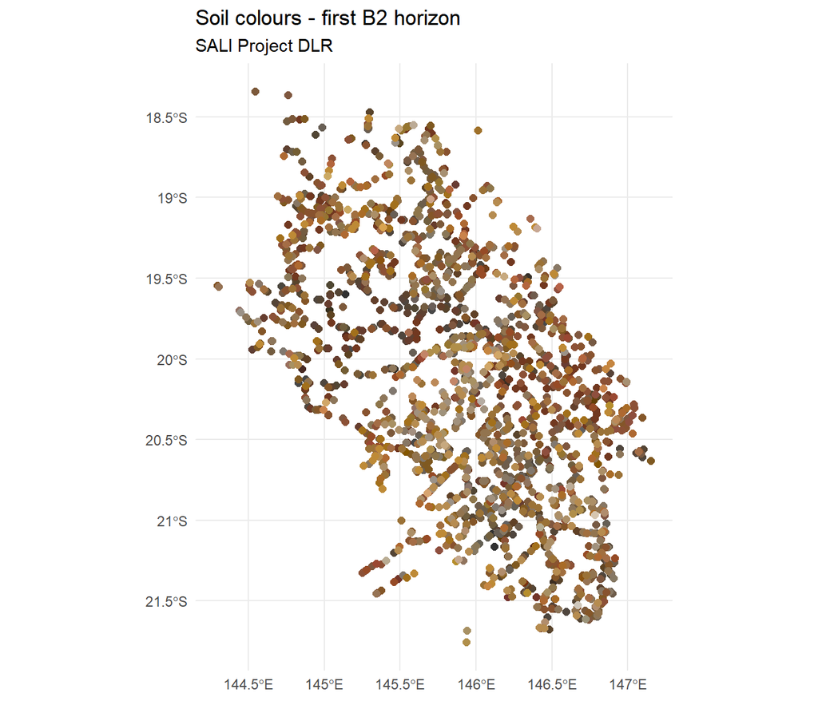

```r
locs <- sit_data[['OLC']] %>%
  st_as_sf(coords = c('LONGITUDE', 'LATITUDE'), crs = 4283) %>%
  dplyr::select(PROJECT_CODE, SITE_ID, OBS_NO)

fancy_bits <-
  reduce(list(max_dist, gilgai, hardset,
              duplexiness, max_scf, max_outcrop, all_depths, h_count,
              hname_max, AB_textures, has_bleach, surf_col, B2_col),
         full_join, by = c('PROJECT_CODE','SITE_ID', 'OBS_NO')) %>%
  left_join(locs, ., by = c('PROJECT_CODE','SITE_ID', 'OBS_NO'))

# e.g.
pltest <- dplyr::filter(fancy_bits, PROJECT_CODE == 'DLR')

cols <- sort(unique(pltest$B2_HEX_COLOUR))

ggplot() +
  geom_sf(data = pltest, aes(colour = B2_HEX_COLOUR), pch = 16, size = 2,
          show.legend = FALSE) +
  scale_colour_manual(values = cols,
                      labels = sort(unique(pltest$B2_HEX_COLOUR))) +
  ggtitle("Soil colours - first B2 horizon", subtitle = "SALI Project DLR") +
  theme_minimal()
```

```r
saveRDS(fancy_bits, file.path(getwd(), 'DERIVED_DATA', 'fancy_bits.rds'))
#fancy_bits <- readRDS(file.path(getwd(), 'DERIVED_DATA', 'fancy_bits.rds'))
```